# Working With BLS Time Series Data

[Back To Blog Page](https://mcmaurer.github.io/Blog/)

Michael Culshaw-Maurer

June 30, 2021

# Load Packages

We’re going to load a handful of packages to pull in BLS data, manipulate data, and demo a little bit of forecasting.

The `fpp3` package corresponds to [this book](https://otexts.com/fpp3/), which uses the [`tidyverts`](https://tidyverts.org/) series of tidy packages for time series.

```r
library(blscrapeR)
library(tidyverse)
library(slider)
library(fpp3)
library(seasonal)
```

# Get Data

Next up we’ll fetch our data using the `bls_api()` function from the `blscrapeR` package. The BLS API only allows for up to 20 years of data in a single request, so we’ll break our range of years into two chunks. We can then request the two ranges of data and bind the rows together to make a single dataframe.

```r
codes <- c("LNS14000000", "CES0000000001", "CUSR0000SA0")

d1 <- bls_api(codes, registrationKey = my_key,
             startyear = 2021-19, endyear = 2021)
```

```
## REQUEST_SUCCEEDED
```

```r
d2 <- bls_api(codes, registrationKey = my_key,
                    startyear = 2021-39, endyear = 2021-20)
```

```
## REQUEST_SUCCEEDED
```

```r
d <- bind_rows(d1, d2)
```

Not sure it’s even necessary to stitch together API calls like this if you work for the BLS, but what do I know?

This approach works fine for a short range of data, but if you have to get a bigger range that requires more requests being stitched together, it can get inefficient. I’ve written a short function that will get any range of data for any number of codes. We won’t use it for this lesson, but you can check it out if you want:

**Function to get N years of data**

```r
get_last_n_years <-
  function(n = 50,
           codes = c("LNS14000000", "CES0000000001", "CUSR0000SA0"),
           registration_key) {

    this_year <- Sys.Date() %>% year()

    d <- seq(from = this_year - n, to = this_year)
    dsplit <- split(d, ceiling(seq_along(d) / 20))

    d <- tibble(min = map_dbl(dsplit, min),
                max = map_dbl(dsplit, max))

    d %>%
      rowwise() %>%
      mutate(data = list(
        bls_api(
          codes,
          registrationKey = registration_key,
          startyear = min,
          endyear = max
        )
      )) %>%
      unnest(data) %>%
      select(-min, -max) %>%
      distinct() %>%
      arrange(year, period)
  }

d <- get_last_n_years(n = 50)
```

## Modifying our dataframe

Let’s take a look at our dataframe:

```r
d
```

```
## # A tibble: 1,419 x 7
##     year period periodName latest value footnotes seriesID
##    <dbl> <chr>  <chr>      <chr>  <dbl> <chr>     <chr>
##  1  2021 M05    May        true     5.8 ""        LNS14000000
##  2  2021 M04    April      <NA>     6.1 ""        LNS14000000
##  3  2021 M03    March      <NA>     6   ""        LNS14000000
##  4  2021 M02    February   <NA>     6.2 ""        LNS14000000
##  5  2021 M01    January    <NA>     6.3 ""        LNS14000000
##  6  2020 M12    December   <NA>     6.7 ""        LNS14000000
##  7  2020 M11    November   <NA>     6.7 ""        LNS14000000
##  8  2020 M10    October    <NA>     6.9 ""        LNS14000000
##  9  2020 M09    September  <NA>     7.8 ""        LNS14000000
## 10  2020 M08    August     <NA>     8.4 ""        LNS14000000
## # … with 1,409 more rows
```

Maybe BLS folks can easily remember what the different codes refer to, but nonetheless, it might be nice to give them slighly more informative names. We’ll make a new column and use the `case_when()` function to give informative names according to the code column. The `case_when()` function is very handy- you write a conditional statement that uses existing columns, then a tilde, then the value the new column should have if that conditional statement is `TRUE`.

The lefthand side of a `case_when()` statement can use multiple columns, like `period_name == “May” & year > 2000`. Any conditional statement that returns `TRUE` or `FALSE` will work.

```r
d <- d %>%
  mutate(metric = case_when(
    seriesID == "LNS14000000" ~ "unemp",
    seriesID == "CES0000000001" ~ "total_emp",
    seriesID == "CUSR0000SA0" ~ "cpi_u",
  ))

d
```

```
## # A tibble: 1,419 x 8
##     year period periodName latest value footnotes seriesID    metric
##    <dbl> <chr>  <chr>      <chr>  <dbl> <chr>     <chr>       <chr>
##  1  2021 M05    May        true     5.8 ""        LNS14000000 unemp
##  2  2021 M04    April      <NA>     6.1 ""        LNS14000000 unemp
##  3  2021 M03    March      <NA>     6   ""        LNS14000000 unemp
##  4  2021 M02    February   <NA>     6.2 ""        LNS14000000 unemp
##  5  2021 M01    January    <NA>     6.3 ""        LNS14000000 unemp
##  6  2020 M12    December   <NA>     6.7 ""        LNS14000000 unemp
##  7  2020 M11    November   <NA>     6.7 ""        LNS14000000 unemp
##  8  2020 M10    October    <NA>     6.9 ""        LNS14000000 unemp
##  9  2020 M09    September  <NA>     7.8 ""        LNS14000000 unemp
## 10  2020 M08    August     <NA>     8.4 ""        LNS14000000 unemp
## # … with 1,409 more rows
```

Another issue is that we have separate columns for years and months, but we’d like to stitch those together into a `date` column that R can work with.

# Intro to **`lubridate`**

You can download the [official `lubridate` cheat sheet](https://github.com/rstudio/cheatsheets/raw/master/lubridate.pdf) for more information.

`lubridate` is a package in the `tidyverse` that makes handling dates and times *slightly* less painful. There are a series of functions that allow you to parse components of dates and times into single date or datetime columns. They are named according to the order of components: `ymd()` will take dates ordered year-month-day, and `mdy_hs()` will take datetimes ordered month-day-year-hour-second. We’ll use the `my()` function to create a date column from our `periodName` and `year` columns.

```r
d <- d %>%
  mutate(date = lubridate::my(paste(periodName, year, sep = "/")))

d
```

```
## # A tibble: 1,419 x 9
##     year period periodName latest value footnotes seriesID    metric date
##    <dbl> <chr>  <chr>      <chr>  <dbl> <chr>     <chr>       <chr>  <date>
##  1  2021 M05    May        true     5.8 ""        LNS14000000 unemp  2021-05-01
##  2  2021 M04    April      <NA>     6.1 ""        LNS14000000 unemp  2021-04-01
##  3  2021 M03    March      <NA>     6   ""        LNS14000000 unemp  2021-03-01
##  4  2021 M02    February   <NA>     6.2 ""        LNS14000000 unemp  2021-02-01
##  5  2021 M01    January    <NA>     6.3 ""        LNS14000000 unemp  2021-01-01
##  6  2020 M12    December   <NA>     6.7 ""        LNS14000000 unemp  2020-12-01
##  7  2020 M11    November   <NA>     6.7 ""        LNS14000000 unemp  2020-11-01
##  8  2020 M10    October    <NA>     6.9 ""        LNS14000000 unemp  2020-10-01
##  9  2020 M09    September  <NA>     7.8 ""        LNS14000000 unemp  2020-09-01
## 10  2020 M08    August     <NA>     8.4 ""        LNS14000000 unemp  2020-08-01
## # … with 1,409 more rows
```

Notice that all of our dates occur on the first day of the month. Date objects in R require year, month, and day, but since we haven’t specified a day, `my()` defaults to the first of the month.

The way Excel handles dates is [particularly weird](https://docs.microsoft.com/en-us/office/troubleshoot/excel/1900-and-1904-date-system).

It’s worth noting that dates and times are often represented differently on different operating systems or in different software. When storing dates in a file, such as a CSV, it’s almost always best to keep the components in separate columns. That way Excel or other programs can’t mess with them, and you can easily use a `lubridate` function to stitch the components together into a date when you need to.

# Plotting time series

Let’s take a look at our time series, just to get a feel for what they look like. We’ll use `ggplot` to make our plots. We’ll put `date` on the x axis and the `value`s on the y axis to make a time series plot. Since the 3 metrics we’re looking at have very different scales, it doesn’t make much sense to plot them all together. Instead, we’ll use `facet_wrap()` to create separate facets for each `metric`. We need to set `scales = "free_y"` so that each metric’s y axis is scaled independently. Finally, we’ll add `theme_minimal()` for a little cleaner appearance.

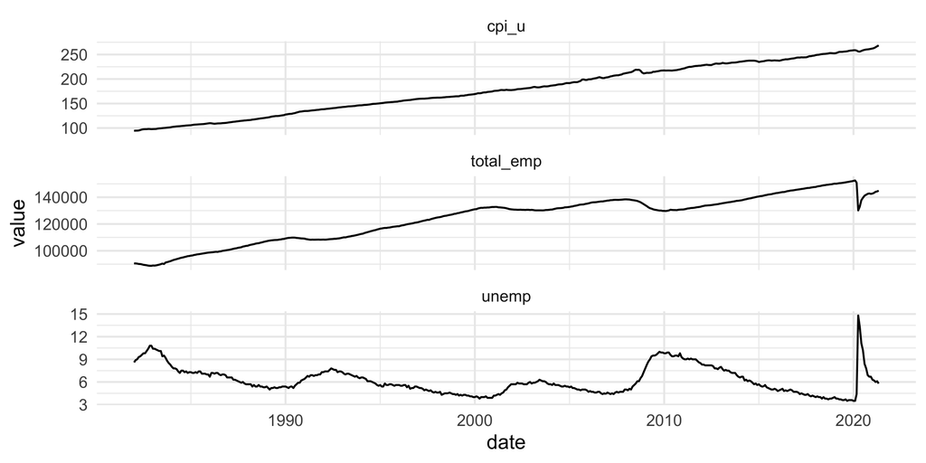

```r
d %>%
  ggplot(aes(x = date, y = value)) +
  geom_line() +
  facet_wrap(vars(metric), ncol = 1, scales = "free_y") +
  theme_minimal()
```

# Moving windows

You can check out the [`slider` website](https://davisvaughan.github.io/slider/) for more information.

One thing we might want to look at is a moving-window or “rolling” average. We’ll use the `slider` package, which has a very flexible interface to make calculations with rolling windows, and its syntax is very similar to the `tidyverse`’s `purrr` package.

There have been a number of similar packages and functions such as `zoo::rollapply()`, `tibbletime::rollify()`, and `tsibble::slide()`, but `slider` is the latest and most flexible approach.

Let’s look at the rolling average of unemployment for the last 10 years. First we’ll `filter()` to get the unemployment values and years from 2011 on. Next we’ll `select()` only the date and value columns, renaming the `value` column to `unemployment`. Then we’ll use `arrange()` to sort our rows by date.

```r
unemp_last10 <- d %>%
  filter(metric == "unemp", year >= 2011) %>%
  select(date, unemployment = value) %>%
  arrange(date)

unemp_last10
```

```
## # A tibble: 125 x 2
##    date       unemployment
##    <date>            <dbl>
##  1 2011-01-01          9.1
##  2 2011-02-01          9
##  3 2011-03-01          9
##  4 2011-04-01          9.1
##  5 2011-05-01          9
##  6 2011-06-01          9.1
##  7 2011-07-01          9
##  8 2011-08-01          9
##  9 2011-09-01          9
## 10 2011-10-01          8.8
## # … with 115 more rows
```

The `slider` package also has functions called `slide_index()` and `slide_period()` that allow for even more flexibility in the way you determine your window. They’re not quite necessary for these monthly time series.

Now we can use a `slide_` function to apply the `mean()` function to a window of unemployment values, with the window sliding along our dates. We’ll use `slide_dbl()` because we want to return a numeric, or double, vector. To get a 5-month average, we set the `.before` and `.after` values to 2.

```r
unemp_last10 <- unemp_last10 %>%
  mutate(five_month_avg = slide_dbl(unemployment, mean,
                                    .before = 2, .after = 2))
```

## Plotting moving window averages

Let’s plot it to take a look at the 5-month average time series.

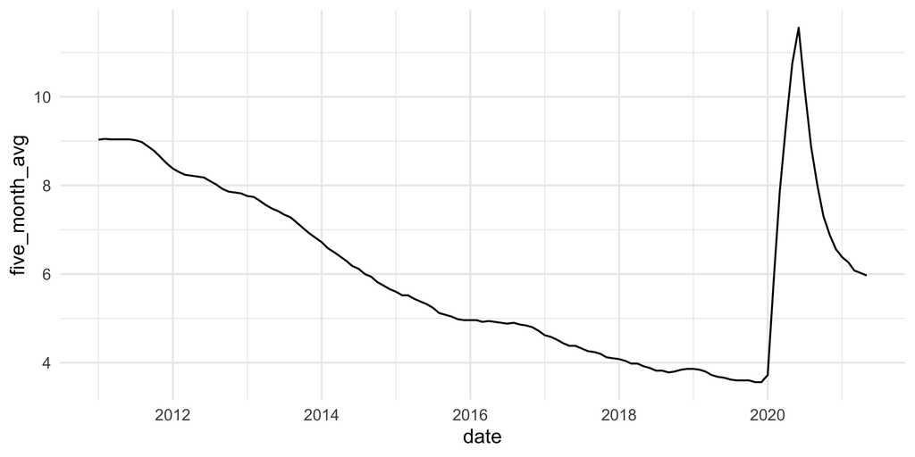

```r
unemp_last10 %>%
  ggplot(aes(x = date, y = five_month_avg)) +
  geom_line() +
  theme_minimal()
```

It’s probably more useful to plot them together, so we can use `pivot_longer()` to bring the `unemployment` and `five_month_average` values into a single column, and then color the lines according to each type.

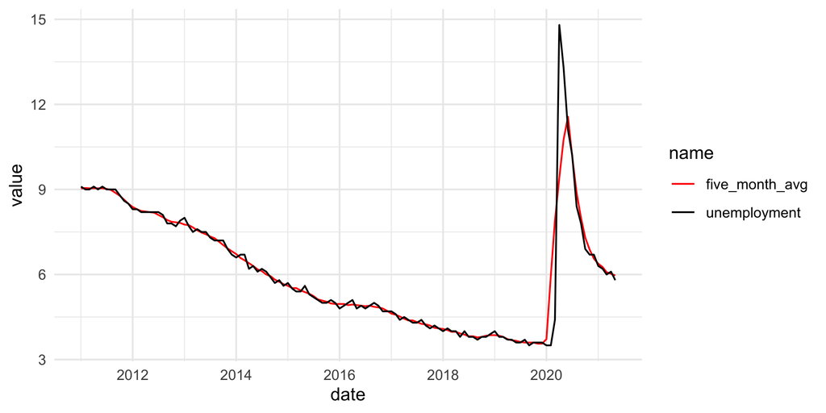

```r
unemp_last10 %>%
  pivot_longer(cols = c(unemployment, five_month_avg)) %>%
  ggplot(aes(x = date, y = value, color = name)) +
  geom_line() +
  scale_color_manual(values = c("red", "black")) +
  theme_minimal()
```

# **`tidyverts`** demo

The [`tidyverts` series of packages](https://tidyverts.org/) is designed to work with time series data in a “tidy” way, meaning it plays well with the broader `tidyverse` set of packages. The developers of these packages have a fantastic book on time series forecasting with `tidyverts`, called [Forecasting: Principles and Practice](https://otexts.com/fpp3/). It goes into great depth and I recommend checking it out, but I’ll do a quick demo of how slick these packages are for working with time series.

## Making a `tsibble` object

The `yearmonth()` function is a bit idiosyncratic to the `tidyverts` packages, and our `ym` column isn’t a “date” in the normal R sense, which is why we’re only using it now.

First, we have to convert our dataframe into a `tsibble` object, which is basically a dataframe that knows that it’s a time series. First we have to make a new column that just hold the “year-month” combination, using the `tsibble` function `yearmonth()`. Then we convert the dataframe to a `tsibble` object with the `ym` column as the time series index.

```r
unemp_last10 <- unemp_last10 %>%
  mutate(ym = yearmonth(date)) %>%
  as_tsibble(index = ym)

unemp_last10
```

```
## # A tsibble: 125 x 4 [1M]
##    date       unemployment five_month_avg       ym
##    <date>            <dbl>          <dbl>    <mth>
##  1 2011-01-01          9.1           9.03 2011 Jan
##  2 2011-02-01          9             9.05 2011 Feb
##  3 2011-03-01          9             9.04 2011 Mar
##  4 2011-04-01          9.1           9.04 2011 Apr
##  5 2011-05-01          9             9.04 2011 May
##  6 2011-06-01          9.1           9.04 2011 Jun
##  7 2011-07-01          9             9.02 2011 Jul
##  8 2011-08-01          9             8.98 2011 Aug
##  9 2011-09-01          9             8.88 2011 Sep
## 10 2011-10-01          8.8           8.78 2011 Oct
## # … with 115 more rows
```

## X13-ARIMA-SEATS time series decomposition

The first thing we’ll do is a quick time series decomposition using the X13-ARIMA-SEATS methods.

The X13-ARIMA-SEATS methods rely on the `seasonal` package, which also installs the X13 binary on your computer.

Next, we use several functions to create two decomposition models. We send our data into the `model()` function, where we define two models: `x11` and `seats`. Both are created using the `X_13ARIMA_SEATS()` functions.

```r
x13_unemp_models <- unemp_last10 %>%
  model(x11 = X_13ARIMA_SEATS(unemployment ~ x11()),
        seats = X_13ARIMA_SEATS(unemployment ~ seats()))
```

Next we take the object containing both models, pass it to the `components()` function, which extracts the model components for plotting, then send that to the `autoplot()` function, which generates a premade `ggplot`, and we add `theme_minimal()` and `scale_color_brewer()` so it looks nice.

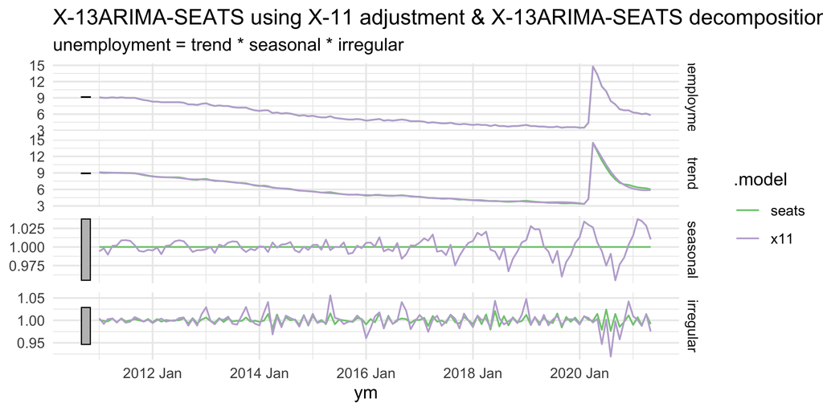

```r
x13_unemp_models %>%
  components() %>%
  autoplot() +
  theme_minimal() +
  scale_colour_brewer(type = "qual")
```

That’s a pretty small amount of code to generate two fairly sophisticated time series decompositions!

## Simple forecasting workflow

The [Forecasting: Principles and Practice](https://otexts.com/fpp3/) book demonstrates some far more sophisticated forecasting methods, I just chose a simple one to show the basic workflow.

Finally, we’ll do a very simple forecast of the data. We again use the `model()` function, but then we use the `RW()` function to generate a random walk model, and use the `drift()` function to do a simple drift model. This basically just draws a line from the starting point to the end point of our time series and projects it forward in time. We then send this to the `forecast()` function and ask it to forecast 3 years into the future. Finally, we send this to `autoplot()` and add in the original `unemp_last10` dataframe so we see the original time series as well as the forecast.

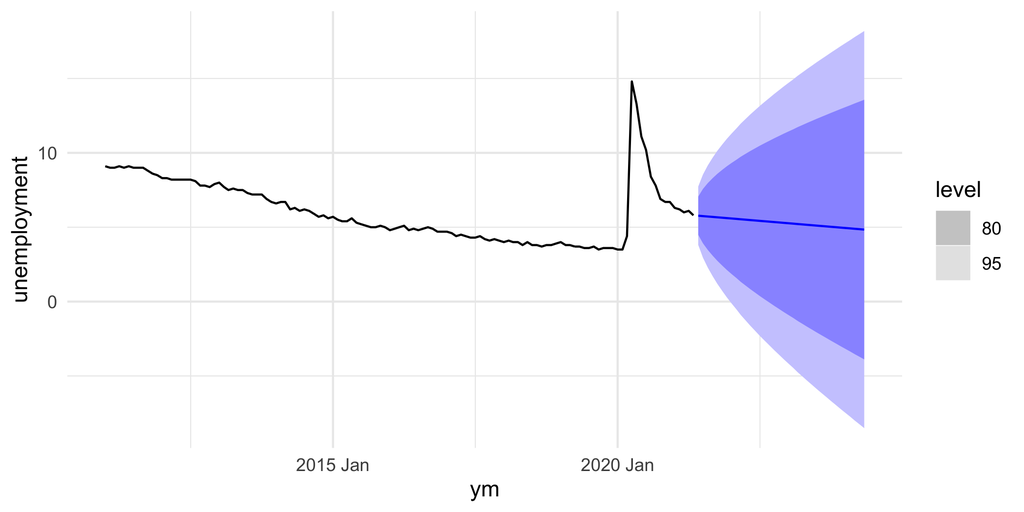

```r
unemp_last10 %>%
  model(RW(unemployment ~ drift())) %>%
  forecast(h = "3 years") %>%
  autoplot(unemp_last10) +
  theme_minimal()
```

Not too bad for only a few lines of code!